# Brasileiro_2021_EFA

Eduardo Cecconi

6/4/2022

```r
library(lavaan)
library(tidyverse)
library(readxl)
library(stats)
library(psych)
library(semPlot)
library(stats)
```

# Análise Fatorial Exploratória

## Dados do Campeonato Brasileiro 2021 extraídos do InStat

O banco de dados é o mesmo, extraído do provedor InStat com 115 variáveis de 379  
jogos do Campeonato Brasileiro 2021; o primeiro passo é o data wrangling, que  
neste caso se baseia na criação da variável “Local”, definindo os mandantes (H)  
e visitantes (A) de cada partida, para servir de referência à construção do  
código de outras quatro variáveis:

- Pontos (Points)
- Gols Concedidos (Goals_Conceded)
- Chutes Concedidos (Shots_Conceded)
- Finalizações Concedidas em Bolas Paradas (Set_Pieces_Conceded)

```r
Brasileiro_2021 <- read_excel("Brasileiro_Matchs_2021.xlsx")

Brasileiro_2021 <- Brasileiro_2021 %>%
                      mutate(Local = rep(c("H", "A"), times = 379)) %>%
                      select(1:3, Local, everything())

Brasileiro_2021 <- Brasileiro_2021 %>%
                      mutate(Goals_Conceded = case_when(
                              Brasileiro_2021$Local == "H" ~ lead(Brasileiro_2021$Goals),
                              Brasileiro_2021$Local == "A" ~ lag(Brasileiro_2021$Goals)),
                             Set_Pieces_Conceded = case_when(
                              Brasileiro_2021$Local == "H" ~ lead(Brasileiro_2021$`Attacks with shots 0 Set pieces attacks` ),
                              Brasileiro_2021$Local == "A" ~ lag(Brasileiro_2021$`Attacks with shots 0 Set pieces attacks`)),
                             Shots_Conceded = case_when(
                              Brasileiro_2021$Local == "H" ~ lead(Brasileiro_2021$`Shots on target`),
                              Brasileiro_2021$Local == "A" ~ lag(Brasileiro_2021$`Shots on target`))) %>%
                             select(1:5, Goals_Conceded, Shots_Conceded, Set_Pieces_Conceded, everything())

Brasileiro_2021 <- Brasileiro_2021 %>%
                      mutate(Points = case_when(
                            Brasileiro_2021$Goals == Brasileiro_2021$Goals_Conceded ~ 1,
                            Brasileiro_2021$Goals > Brasileiro_2021$Goals_Conceded ~ 3,
                            Brasileiro_2021$Goals < Brasileiro_2021$Goals_Conceded ~ 0)) %>%
                      select(1:3, Points, everything())
```

Das 120 variáveis resultantes, 39 foram selecionadas para a elaboração das métricas,  
formando um novo banco de dados com 24 variáveis:

```r
Metrics_EFA <- Brasileiro_2021 %>% select(Teams, Points, Goals, Goals_Conceded,
                                             `Accurate passes`, Fouls, Passes,
                                             `Key passes accurate`, `Ball recoveries`,
                                             `Ball possession, %`, `Ball possessions, quantity`,
                                             `Ball recoveries in opponent's half`,
                                             `Team pressing successful`, `Opponent's xG`,
                                             `xG (Expected goals)`, `Dribbles successful`,
                                             `Defensive challenges won`,  Building0ups,
                                             `Ball interceptions`, `High pressing successful`,
                                             `Low pressing successful`, `Expected points`,
                                             `Opponent's passes per defensive action`,
                                             `Average duration of ball possession, min`,
                                             `Positional attacks with shots`,
                                             `Counter0attacks with a shot`, `Yellow cards`,
                                             `Red cards`, `Crosses accurate`,
                                             `Attacking challenges won`,
                                             `Air challenges won`, `Tackles successful`,
                                             `Lost balls`, `Lost balls in own half`,
                                             `Entrances on opponent's half`,
                                             `Entrances on final third of opponent's half`,
                                             `Entrances to the opponent's box`,
                                             `Attacks with shots 0 Set pieces attacks`,
                                              Set_Pieces_Conceded, Shots_Conceded) %>%
                                       rename(Expected_Points = `Expected points`,
                                              xG = `xG (Expected goals)`,
                                              Positional_shot = `Positional attacks with shots`,
                                              Counter_shot = `Counter0attacks with a shot`,
                                              Set_Piece_shot = `Attacks with shots 0 Set pieces attacks`,
                                              Key_Passes_acc = `Key passes accurate`,
                                              Crosses_acc = `Crosses accurate`,
                                              Dribbles_acc = `Dribbles successful`,
                                              xG_Conceded = `Opponent's xG`,
                                              Interceptions = `Ball interceptions`,
                                              Team_Pressing = `Team pressing successful`,
                                              High_press_acc = `High pressing successful`,
                                              Low_press_acc = `Low pressing successful`,
                                              Recoveries = `Ball recoveries`,
                                              Recoveries_High = `Ball recoveries in opponent's half`,
                                              PPDA = `Opponent's passes per defensive action`,
                                              Duels_def = `Defensive challenges won`,
                                              Duels_ata = `Attacking challenges won`,
                                              Duels_air = `Air challenges won`,
                                              Tackles_acc = `Tackles successful`,
                                              Yellow_Card = `Yellow cards`,
                                              Red_Card = `Red cards`,
                                              Passes_acc = `Accurate passes`,
                                              Possession_Time = `Ball possession, %`,
                                              Possession_Quant = `Ball possessions, quantity`,
                                              Time_per_possession = `Average duration of ball possession, min`,
                                              Build_Total = Building0ups,
                                              Lost_Balls = `Lost balls`,
                                              Lost_Balls_own = `Lost balls in own half`,
                                              Second_third = `Entrances on opponent's half`,
                                              Final_third = `Entrances on final third of opponent's half`,
                                              Box = `Entrances to the opponent's box`) %>%
                                       mutate(Conversion = Goals / xG,
                                              Conversion_Points = Points / Expected_Points,
                                              Attacks_Shot = Positional_shot +
                                                             Counter_shot + Set_Piece_shot,
                                              Shot_Assist = Key_Passes_acc + Crosses_acc,
                                              Conversion_Conceded = Goals_Conceded /
                                                                    xG_Conceded,
                                              Imposition = (Duels_def + Duels_ata + Duels_air) -
                                                           (Fouls + Red_Card + Yellow_Card),
                                              Contention = log(Tackles_acc + Recoveries +
                                                           Interceptions + Low_press_acc),
                                              Pressing = Recoveries_High + High_press_acc +
                                                         Team_Pressing,
                                              Ball_Care = log((Passes_acc + Dribbles_acc) - Lost_Balls),
                                              Passing_Speed = 10* ((Passes / Possession_Quant) /
                                                              Time_per_possession),
                                              Build_Up = Build_Total - Lost_Balls_own,
                                              Progression = (Second_third - Final_third) +
                                                            (Final_third - Box)) %>%
                                       select(Teams, Points, Expected_Points,
                                              Conversion_Points, Goals, xG, Attacks_Shot,
                                              Conversion, Shot_Assist, Goals_Conceded,
                                              xG_Conceded, Conversion_Conceded, Shots_Conceded,
                                              Contention, Pressing, Imposition, PPDA,
                                              Possession_Time, Passing_Speed, Ball_Care,
                                              Build_Up, Progression, Set_Piece_shot,
                                              Set_Pieces_Conceded)
```

Abaixo resumo os conceitos utilizados na elaboração das métricas. Vale  
destacar que eles foram definidos a partir da análise das variáveis e das  
consequentes possibilidades de manipulação delas; um banco de dados diferente,  
com outras variáveis que não estas providas pelo InStat, provavelmente exigiria  
adaptações, incluindo exclusão de alguns e criação de novos. São eles:

- **Conversion:** razão entre os gols marcados e a expectativa de gol (xG), para  
  privilegiar a eficiência;
- **Attacks_Shot:** soma dos chutes realizados em 3 origens distintas de ataques  
  (Posicionais, Transições e Bolas Paradas), o que na execução em si da AFC tem  
  pouca importância, mas pode subsidiar paralelamente gráficos para identificar  
  diferentes estilos de jogo ofensivo;
- **Shot_Assist:** soma dos passes-decisivos e dos cruzamentos que geraram  
  finalização;
- **Conversion_Conceded:** razão entre gols sofridos e expectativa concedida;
- **Imposition:** soma das vitórias pessoais em três tipos de duelos listados  
  (ofensivos, defensivos e aéreos), subtraída a soma de três tipos de infrações  
  (faltas cometidas, cartões amarelos e vermelhos recebidos);
- **Contention:** soma de quatro ações defensivas listadas: tackles (um item de scout  
  comum nas plataformas dominantes mas que, na prática, não existe no Brasil, onde  
  o conceito disseminado é uma espécie de fusão entre tackles e recoveries - a  
  **Roubada**), recuperações, interceptações e pressão baixa eficiente;
- **Pressing:** soma de três ações de pressão listadas: recuperações no campo de  
  ataque, pressão alta eficiente e o que o InStat chama de “team pressing”, e que  
  embora vago quando analisado nos vídeos, é uma espécie de “pressão na bola”;
- **Ball_Care:** relação entre passes certos e dribles certos com as perdas de bola;
- **Passing_Speed:** este indicador é uma adaptação do conceito de VEL (velocidade  
  de circulação da bola); sem a cronologia das ações nos dados extraídos, estimei o  
  tempo individual de retenção da bola por jogada através do cruzamento de três  
  variáveis originais: passes certos, quantidade de posses de bola e tempo médio  
  (em segundos) de cada posse;
- **Build-up:** subtração entre a variável “construção”, disponibilizada nos dados  
  originais, e perdas de bola no próprio campo;
- **Progression:** relação entre as quantidades de ingressos da equipe do campo de  
  defesa para o de ataque, do campo de ataque para o terço final, e do terço final  
  para a área adversária;
- **PPDA:** Passes permitidos por ação defensiva, em inglês, variável que já foi  
  entregue originalmente pelo InStat, sem necessitar de manipulação. Conta a  
  quantidade de passes que o adversário troca na construção até que a equipe realize  
  alguma ação defensiva.

Na AFE as matrizes de variância, covariância e correlação são muito importantes, pois amparam as análises dos testes estatísticos. Nesta técnica ainda não sabemos  
exatamente como vamos manipular os dados, logo os testes serão os guias do analista  
para a construção do modelo (quais métricas descartar, quais vão se relacionar, etc).

```r
correlation <- cor(Metrics_EFA[ , 2:24])

covariance <- cov(Metrics_EFA[ , 2:24])

variance <- var(Metrics_EFA[ , 2:24])
```

## Teste de Esfericidade de Bartlett

Com p-valor inferior ao nível de significância de 5%, é possível rejeitar a  
hipótese nula e afirmar que as variáveis têm correlação suficiente para aplicar  
as técnicas de análise fatorial, de análise de componentes principais ou de  
regressão. Testadas as 758 observações da matriz de correlações, o p-valor foi  
igual a zero, o que justifica o procedimento.

```r
cortest.bartlett(correlation, n = 758)
```

```
## $chisq
## [1] 11610.49
##
## $p.value
## [1] 0
##
## $df
## [1] 253
```

## #KMO (KAISER-MEYER-OLKIN MEASURE OF SAMPLING ADEQUACY)

Outro teste para validar a escolha pela Análise Fatorial Exploratória é o KMO,  
que tem parâmetro a partir de 0.5. Como o valor geral do teste aplicado chegou  
a 0.68, o KMO reforça que há correlação entre as variáveis.

```r
KMO(Metrics_EFA[ , 2:24])
```

```
## Kaiser-Meyer-Olkin factor adequacy
## Call: KMO(r = Metrics_EFA[, 2:24])
## Overall MSA =  0.68
## MSA for each item =
##              Points     Expected_Points   Conversion_Points               Goals
##                0.75                0.75                0.67                0.59
##                  xG        Attacks_Shot          Conversion         Shot_Assist
##                0.66                0.88                0.63                0.91
##      Goals_Conceded         xG_Conceded Conversion_Conceded      Shots_Conceded
##                0.62                0.62                0.55                0.90
##          Contention            Pressing          Imposition                PPDA
##                0.53                0.70                0.75                0.23
##     Possession_Time       Passing_Speed           Ball_Care            Build_Up
##                0.61                0.31                0.61                0.88
##         Progression      Set_Piece_shot Set_Pieces_Conceded
##                0.81                0.83                0.91
```

Dois aspectos chamam a atenção na tabela de valores do teste KMO: os resultados  
dos indicadores Passing_Speed (uma estimativa de VEL, como já foi explicado) e  
PPDA. Ambos são conceitos atrelados ao imaginário do futebol moderno, sendo a  
velocidade de circulação da bola um princípio levado em alta consideração por  
treinadores simpáticos ao jogo posicional, por exemplo. Estatisticamente, entretanto,  
a variável Passing_Speed apresentou baixo índice de correlação (apenas 0.31),  
enquanto o PPDA (um indicador de pressão alta defensiva) não passou de 0.23.

A baixa correlação do Passing_Speed com este banco de dados do Brasileiro 2021 vai  
ficar muito evidente no artigo com uma regressão múltipla que vou publicar  
a seguir, mas já pode ser observada na tabela abaixo. Naturalmente, por ser  
um indicador com valor inversamente proporcional ao desempenho (quanto menor,  
melhor), esperava-se que Passing_Speed tivesse correlação negativa com os pontos,  
porém o valor é de -0.02 na tabela demonstrada abaixo (ou seja, muito próximo de zero).  
O que permite concluir que **a velocidade de circulação da bola não foi determinante**  
**para conquistar pontos no Brasileiro.**

Ainda falando em posse de bola, a variável Possession_Time tem correlação negativa  
com os pontos (-0.10), também contrariando o conceito vigente de dominação pela  
posse de bola para obter vitórias - pelo menos, não foi isso que se verificou no  
Campeonato Brasileiro do ano passado. Na verdade, **ter menor posse de bola que o**  
**adversário foi mais influente para conquistar pontos**.

```r
lowerCor(Metrics_EFA[ , 2:24])
```

```
##                     Ponts Exp_P Cnv_P Goals xG    Att_S Cnvrs Sht_A Gls_C xG_Cn
## Points               1.00
## Expected_Points      0.38  1.00
## Conversion_Points    0.47 -0.27  1.00
## Goals                0.64  0.30  0.26  1.00
## xG                   0.31  0.75 -0.13  0.43  1.00
## Attacks_Shot         0.18  0.57 -0.16  0.23  0.66  1.00
## Conversion           0.44 -0.12  0.42  0.69 -0.10 -0.10  1.00
## Shot_Assist          0.10  0.48 -0.13  0.15  0.57  0.56 -0.12  1.00
## Goals_Conceded      -0.58 -0.28 -0.30  0.02 -0.05 -0.04  0.06 -0.04  1.00
## xG_Conceded         -0.29 -0.70  0.29 -0.05 -0.18 -0.24  0.07 -0.21  0.43  1.00
## Conversion_Conceded -0.40  0.12 -0.31  0.06  0.07  0.11  0.03  0.14  0.69 -0.10
## Shots_Conceded      -0.28 -0.42  0.06  0.01 -0.13 -0.19  0.10 -0.18  0.48  0.60
## Contention           0.18 -0.03  0.19  0.08 -0.01 -0.03  0.10 -0.05 -0.20  0.02
## Pressing             0.10  0.32 -0.13  0.07  0.23  0.33 -0.07  0.29 -0.11 -0.29
## Imposition           0.02  0.16  0.00 -0.01  0.16  0.21 -0.09  0.18 -0.10 -0.10
## PPDA                -0.03  0.03 -0.09  0.03 -0.02 -0.04  0.00 -0.04  0.14 -0.07
## Possession_Time     -0.10  0.33 -0.27 -0.03  0.27  0.45 -0.18  0.39  0.03 -0.27
## Passing_Speed       -0.02  0.06 -0.09  0.01  0.01  0.03 -0.01  0.10  0.04 -0.10
## Ball_Care           -0.06  0.29 -0.26  0.00  0.20  0.39 -0.12  0.34  0.05 -0.27
## Build_Up            -0.17  0.14 -0.25 -0.09  0.09  0.19 -0.17  0.16  0.11 -0.17
## Progression         -0.17  0.23 -0.25 -0.19  0.13  0.36 -0.24  0.27  0.01 -0.24
## Set_Piece_shot       0.05  0.40 -0.16  0.11  0.48  0.57 -0.10  0.32  0.04 -0.16
## Set_Pieces_Conceded -0.04 -0.39  0.27  0.04 -0.16 -0.20  0.14 -0.16  0.11  0.48
##                     Cnv_C
## Points
## Expected_Points
## Conversion_Points
## Goals
## xG
## Attacks_Shot
## Conversion
## Shot_Assist
## Goals_Conceded
## xG_Conceded
## Conversion_Conceded  1.00
## Shots_Conceded       0.15
## Contention          -0.18
## Pressing             0.06
## Imposition          -0.01
```

[output cut: 20 more lines]

```
## Set_Pieces_Conceded  0.37  0.07 -0.24 -0.09 -0.15 -0.26 -0.09 -0.31 -0.21 -0.27
##                     St_P_
## Shots_Conceded
## Contention
## Pressing
## Imposition
## PPDA
## Possession_Time
## Passing_Speed
## Ball_Care
## Build_Up
## Progression
## Set_Piece_shot       1.00
## Set_Pieces_Conceded -0.16
## [1]  1.00
```

##Velocidade de circulação (tempo de retenção) x Tempo de posse

Abrindo um breve parênteses no processo de AFE, apresento um gráfico de dispersão  
comparando as variáveis numéricas Passing_Speed (VEL estimada, tempo de retenção,  
velocidade de circulação, enfim, há várias nomenclaturas possíveis) e Possession_Time.

Em relação ao código, primeiro extraí apenas as variáveis de interesse e agrupei  
pelos times, para então executar as funções de estatística descritiva (média de VEL  
e de posse, e total de pontos).

O campeão Atlético-MG, por exemplo, teve a 2ª retenção mais alta, superado apenas  
pelo Corinthians, ambos com tempo médio de posse superior a 50% (ou seja, ambos  
foram dominantes em posse, porém com velocidade baixa de circulação). O São Paulo  
se aproximou do Atlético-MG nas duas variáveis, porém a performance em pontos foi  
muito inferior.

Já a Chapecoense, pior equipe do Brasileiro, teve VEL média estimada em menos de  
2.9 segundos (8ª circulação mais ágil), o que não teve nenhum impacto em sua  
performance prática.

Palmeiras e Bragantino foram as equipes que conseguiram associar agilidade  
na circulação da bola, tempo de posse superior e boa performance em pontos,  
enquanto o Fortaleza se aproximou de ambos mas dividiu o controle da bola  
com os adversários.

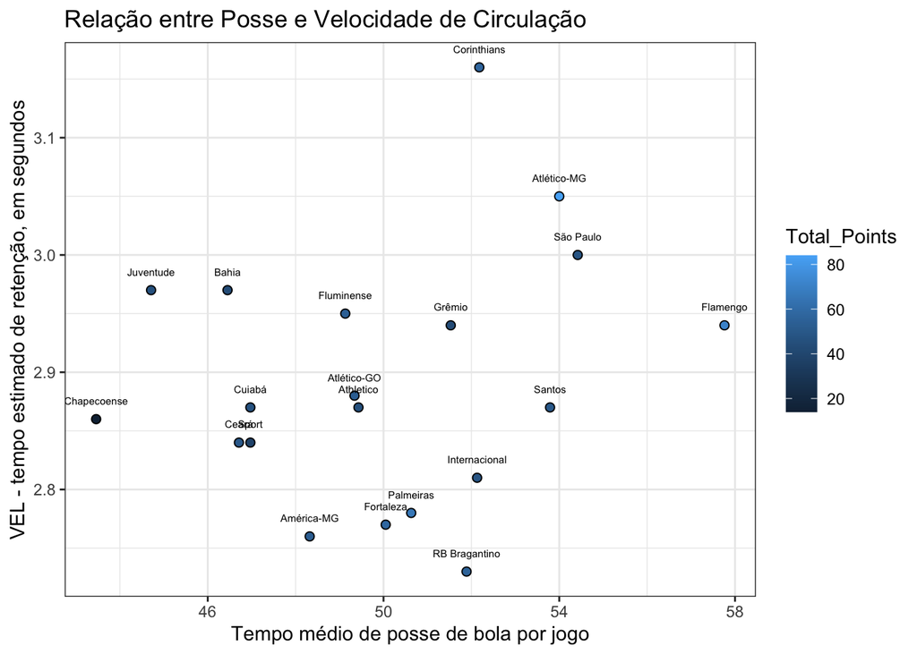

```r
Vel_Possession <- Metrics_EFA %>% group_by(Teams) %>%
                                  summarise(VEL=mean(Passing_Speed),
                                            Posse=mean(Possession_Time),
                                            Total_Points=sum(Points)) %>%
                                  mutate(Posse = Posse * 100) %>%
                                  select(Teams, VEL, Posse, Total_Points) %>%
                                  mutate_if(is.numeric, round, 2)


ggplot(data = Vel_Possession, mapping = aes(x = Posse, y = VEL, fill = Total_Points)) +
      geom_point(alpha=3, shape=21, size = 2) +
      geom_text(aes(label = Teams), size = 2, color="black", vjust = -2) +
      theme_bw() +
      theme(legend.position="bottom") +
      labs(title = "Relação entre Posse e Velocidade de Circulação",
           y = "VEL - tempo estimado de retenção, em segundos",
           x = "Tempo médio de posse de bola por jogo") +
      theme(legend.position = "right")
```

Voltando à AFE, após realizar os testes e analisar a matriz de correlações, o passo  
seguinte é estimar o número de fatores necessários para melhor sintetizar as informações  
contidas no banco de dados, com a função de análise paralela (**Parallel Analysis**):

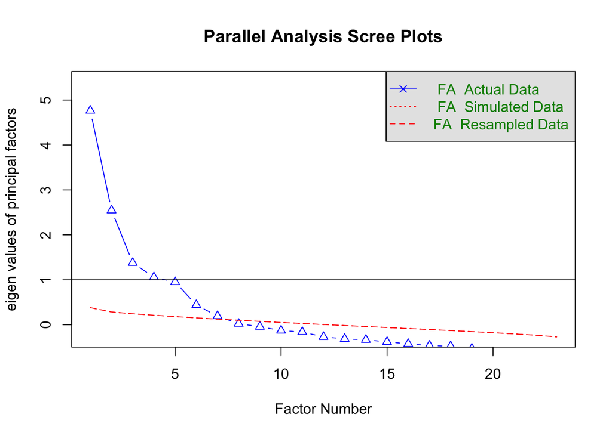

```
## Parallel analysis suggests that the number of factors =  7  and the number of components =  NA
```

```r
fa.parallel(Metrics_EFA[ , 2:24],fm="pa", fa="fa", n.iter=500)
```

```r
fit <- fa(Metrics_EFA[ , 2:24], nfactors = 4, rotate = "Promax", scores = TRUE, fm = "ml")
```

No comando acima, o método de extração escolhido (fm - factor method) foi Maximum  
Likelihood (ML), depois que uma tentativa com Principal Axis Factor (PA) gerou a  
mensagem de erro *“The estimated weights for the factor scores are probably incorrect.*  
*Try a different factor score estimation method”*.

A rotação escolhida foi oblíqua (Promax) porque assumimos que há correlação entre  
os fatores, o que é lógico de se imaginar tratando-se de uma análise esportiva (os  
processos se encadeiam). Caso fosse uma rotação ortogonal, assumiríamos que os  
fatores não têm relação.

O fator **ML4** explica 32% dos dados; o **ML2** explica 28% dos dados; e os fatores  
**ML3** e **ML1** explicam 20% dos dados cada, somando a proporção cumulativa de 100%.

O índice **TLI** (Tucker-Lewis Index) chegou a **0.564** (ideal é > 0.9) e o **RMSEA**  
foi de **0.16** (ideal < 0.05). Como já foi dito no artigo com a Análise Fatorial  
Confirmatória, os modelos de indicadores para futebol aparentam se inclinar para  
resultados baixos nos índices de ajuste, o que suponho esteja relacionado com a  
imprevisibilidade de um esporte onde nem sempre o melhor vence, e onde temos  
inúmeros registros de equipes derrotadas com maior posse, mais finalizações, enfim,  
melhores indicadores que o adversário. O teste estatístico mede as correlações e  
não consegue, obviamente, enxergar este contexto próprio do futebol.

Inspirado em outras pesquisas publicadas, estabeleci o corte de variáveis com  
cargas de correlação inferiores a 0.30, e criei uma nova matriz com os quatro fatores  
sugeridos pela EFA, organizados de forma decrescente (das maiores cargas para as menores):

```r
print(fit, cut = .30, sort = TRUE, digits = 3)
```

```
## Factor Analysis using method =  ml
## Call: fa(r = Metrics_EFA[, 2:24], nfactors = 4, rotate = "Promax",
##     scores = TRUE, fm = "ml")
## Standardized loadings (pattern matrix) based upon correlation matrix
##                     item    ML4    ML2    ML3    ML1     h2     u2  com
## Expected_Points        2  1.023                      0.9375 0.0625 1.05
## xG                     5  0.833                      0.6472 0.3528 1.32
## xG_Conceded           10 -0.647                0.321 0.5517 0.4483 1.54
## Attacks_Shot           6  0.568                      0.4441 0.5559 1.36
## Set_Piece_shot        22  0.488                      0.2312 0.7688 1.20
## Shot_Assist            8  0.482                      0.3208 0.6792 1.26
## Set_Pieces_Conceded   23 -0.351                      0.2238 0.7762 1.66
## Pressing              14                             0.1672 0.8328 1.91
## Imposition            15                             0.0426 0.9574 1.61
## Ball_Care             19         1.041               0.9442 0.0558 1.03
## Possession_Time       17         0.875               0.7822 0.2178 1.00
## Build_Up              20         0.836               0.6037 0.3963 1.08
## Passing_Speed         18         0.539               0.2115 0.7885 1.22
## Progression           21         0.448               0.3535 0.6465 1.52
## Contention            13        -0.316               0.1368 0.8632 1.72
## Goals                  4                0.977        0.9247 0.0753 1.26
## Conversion             7                0.821        0.6503 0.3497 1.20
## Points                 1  0.307         0.627 -0.457 0.8081 0.1919 2.34
## Conversion_Points      3 -0.344         0.391 -0.334 0.4549 0.5451 2.94
## Goals_Conceded         9                       0.996 0.9950 0.0050 1.09
## Conversion_Conceded   11                       0.759 0.5977 0.4023 1.17
## Shots_Conceded        12 -0.339                0.442 0.3678 0.6322 2.22
## PPDA                  16                             0.0293 0.9707 1.97
##
##                         ML4   ML2   ML3   ML1
## SS loadings           3.645 3.158 2.283 2.340
## Proportion Var        0.158 0.137 0.099 0.102
## Cumulative Var        0.158 0.296 0.395 0.497
## Proportion Explained  0.319 0.276 0.200 0.205
## Cumulative Proportion 0.319 0.595 0.795 1.000
##
##  With factor correlations of
##        ML4    ML2    ML3    ML1
## ML4  1.000  0.508 -0.089 -0.027
## ML2  0.508  1.000 -0.290  0.153
```

[output cut: 9 more lines]

```
## The root mean square of the residuals (RMSR) is  0.077
## The df corrected root mean square of the residuals is  0.095
##
## The harmonic number of observations is  758 with the empirical chi square  2300.254  with prob <  0
## The total number of observations was  758  with Likelihood Chi Square =  3420.997  with prob <  0
##
## Tucker Lewis Index of factoring reliability =  0.5644
## RMSEA index =  0.1603  and the 90 % confidence intervals are  0.1558 0.1651
## BIC =  2313.673
## Fit based upon off diagonal values = 0.914
## Measures of factor score adequacy
##                                                     ML4   ML2   ML3   ML1
## Correlation of (regression) scores with factors   0.977 0.980 0.969 0.996
## Multiple R square of scores with factors          0.955 0.961 0.940 0.992
## Minimum correlation of possible factor scores     0.909 0.923 0.879 0.985
```

```r
Pattern_Matrix <- fit$loadings[1:23, ]

fit$Structure[1:23, ]
```

```
##                             ML4         ML2           ML3         ML1
## Points               0.25416113 -0.11344867  0.7126391570 -0.61591835
## Expected_Points      0.95106494  0.35655708  0.0385735779 -0.13176342
## Conversion_Points   -0.36406033 -0.32823570  0.4975350223 -0.41522734
## Goals                0.21798197 -0.06166355  0.8936003286 -0.04257895
## xG                   0.74384452  0.24873047  0.1895269733  0.04902036
## Attacks_Shot         0.63898630  0.42945146  0.0227803707  0.06229070
## Conversion          -0.21313355 -0.20282613  0.7782974194 -0.06095155
## Shot_Assist          0.54865349  0.37914228 -0.0267006341  0.04861725
## Goals_Conceded      -0.20076291  0.04569426 -0.1107286214  0.97626610
## xG_Conceded         -0.67376112 -0.32789130  0.0988276977  0.30971960
## Conversion_Conceded  0.19165188  0.21334472 -0.1480595169  0.74191186
## Shots_Conceded      -0.42765786 -0.26846204  0.0709142770  0.40609861
## Contention          -0.07902432 -0.31149223  0.1589691043 -0.22953369
## Pressing             0.37537897  0.31723736 -0.0494055860 -0.04808751
## Imposition           0.18609037  0.07450117 -0.0626795222 -0.06245391
## PPDA                 0.02628921 -0.02726429 -0.0004086895  0.14812582
## Possession_Time      0.47097959  0.88393710 -0.2406912898  0.12567933
## Passing_Speed        0.11185001  0.43339614 -0.0498987266  0.05691614
## Ball_Care            0.42732275  0.96445414 -0.1955713443  0.13013306
## Build_Up             0.26235982  0.76213162 -0.2460919119  0.17505719
## Progression          0.34726171  0.55712838 -0.3413620741  0.10554053
## Set_Piece_shot       0.45886267  0.22013401 -0.0500048744  0.12414132
## Set_Pieces_Conceded -0.43392305 -0.34380362  0.1821869259  0.01927034
```

Os nomes dos fatores são determinados pelo pesquisador a partir da análise dos  
resultados da análise exploratória, ou seja, da identificação das variáveis que  
têm as maiores cargas em cada um deles. Caso não veja necessidade de nomeá-los,  
o pesquisador pode apenas manter o padrão da EFA - neste exemplo, os fatores estão  
batizados como ML, de Maximum Likelihood.

Se esta pesquisa fosse levada adiante e implementada como um método de trabalho,  
o fator **ML4** poderia ser chamado de **Expectativa**, pois nele as maiores cargas  
estão relacionadas com **Expected_Points, xG e xG_Conceded**.

O fator **ML2** encontrou a correlação entre as variáveis de **Posse**, e assim poderia  
ser chamado. As cargas são altas para **Ball_Care, Possession_Time e Build_Up**. Mais  
uma vez nota-se que a variável **Passing_Speed** não alcançou correlação próxima às  
demais (0.43, contra 0.96 de Ball_Care, por exemplo).

E o fator **ML1** é o inverso do ML3, ou seja, ele carrega as variáveis que mais  
influenciaram na **perda de pontos**. Nota-se que despontam apenas as cargas de  
**Goals_Conceded e Conversion_Conceded**. Como poderia ser nomeado este fator? Talvez  
seria o caso de chamar o **ML3** de **Eficiência Ofensiva** e o **ML1** de **Eficiência**  
**Defensiva**.

Ao contrário da Análise Fatorial Confirmatória, onde o modelo privilegia aspectos  
estilísticos, para identificar padrões de comportamento relacionados com o modelo de  
jogo ds equipes, a Análise Fatorial Exploratória encontrou correlações mais fortes  
no que diz respeito às conversões (seja de gols feitos ou sofridos, seja de pontos),  
sendo que apenas o fator **ML2** assemelha-se ao modelo testado na AFC, ao correlacionar  
as variáveis de posse.

Abaixo apresento o diagrama do modelo resultante:

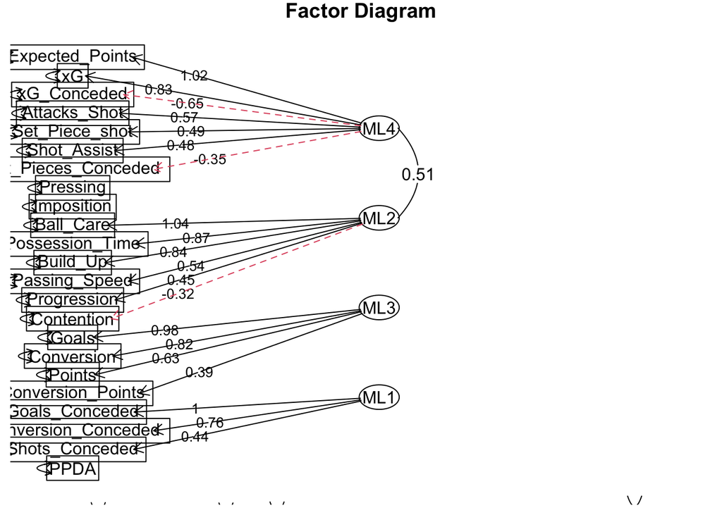

```r
fa.diagram(fit, digits = 2, main = "Factor Diagram",
           cut = .30,
           simple = T,
           errors = T)
```

##Ranking  
Assim como na análise confirmatória, também é possível rankear as observações (neste  
caso, as equipes) na análise exploratória. Para isso, mantive a simplicidade matemática,  
sem criar pesos com multiplicações ou exponenciações. O ranking levará em conta a  
soma dos 3 fatores positivos (ML4, ML2 e ML3) subtraídos pelo ML1, que tem carga inversa  
(quanto menor a pontuação obtida, melhor, afinal ele encontra as correlações entre  
pontos e gols/conversão concedidos).

```r
Scores <- factor.scores(Metrics_EFA[ , 2:24],fit,
                         Phi = NULL,
                         method = "tenBerge",
                         rho=NULL)

Scores <- as.data.frame(Scores$scores)

Scores_Bind <- bind_cols(Metrics_EFA, Scores)

Scores_Bind <- Scores_Bind %>% select(1, 25:28) %>%
                                 mutate(Ranking = ML4 + ML2 + ML3 - ML1) %>%
                                 select(Teams, Ranking, everything())

Scores_Final <- Scores_Bind %>% group_by(Teams) %>%
                                summarise(Ranking_Total=sum(Ranking),
                                          ML4_Total=sum(ML4),
                                          ML2_Total=sum(ML2),
                                          ML3_Total=sum(ML3),
                                          ML1_Total=sum(ML1)) %>%
                                mutate(Expectancy = ML4_Total,
                                       Possession = ML2_Total,
                                       Efficiency_Off = ML2_Total,
                                       Efficiency_Def = ML1_Total) %>%
                                select(Teams, Ranking_Total, Expectancy,
                                       Possession, Efficiency_Off, Efficiency_Def) %>%
                                mutate_if(is.numeric, round, 2) %>%
                                arrange(desc(Ranking_Total))
```

Chama a atenção o rebaixado Grêmio, que terminou em 7º no ranking geral, e foi o 3º  
com a maior Expectativa - mais uma vez a ineficiência defensiva da equipe demonstra  
que este foi o fator determinante para a queda.

Outro rebaixado, o Bahia, também criou expectativa suficiente para escapar (13º), mas  
foi o 3º pior em todos os demais fatores - ou seja, ineficiente em todos os processos.  
O Sport Recife teve situação inversa: destacou-se pela eficiência defensiva (5º) e  
ficou em posições intermediárias em ataque e posse, porém terminou em 19º no ranking  
devido à baixíssima expectativa criada - mesmo obtendo performance acima do esperado,  
não foi o suficente para evitar o rebaixamento.

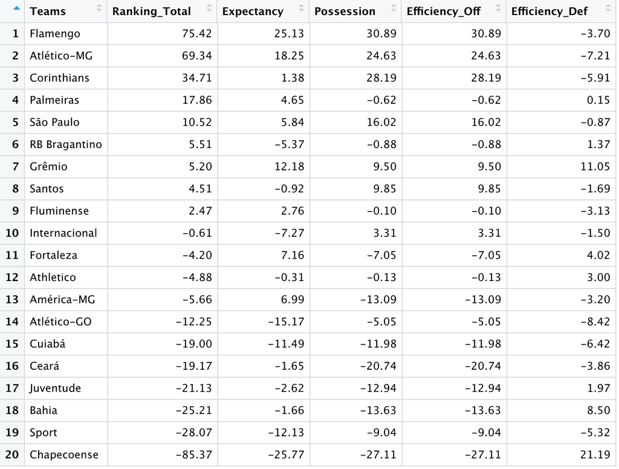

São muitas as considerações possíveis no cruzamento dos resultados das duas análises  
apresentadas, assim como há outros tantos aspectos inexplorados para não tornar este  
artigo ainda mais extenso e cansativo. Em breve publicarei os resultados de uma regressão  
múltipla baseada no mesmo banco de dados.